# Severe Weather Impacts on the United States Public Health and Economy: Analysis of NOAA Reports, 1996 - 2011

vstarkweather

March 18, 2015

## 2. Data Processing

#### Obtain the NOAA data, and configure R for the analysis.

The R code for producing the analysis is shown in this section. 1. Check to see if the required R packages are loaded, and load them if needed.

```r
        # load required packages through this neat trick
libs <- c("lubridate","knitr","ggplot2","scales", "gridExtra","tidyr","dplyr")
        # check to see if packages are already installed
x <- sapply(libs,function(x) if(!require(x,character.only = T))
        install.packages(x))
rm(x,libs)
```

2. Check to see if the required NOAA data file already exists in the working directory.
- If needed, capture URL for data, and download the file.
3. Load the data into the analysis as the data frame `checkRawData`.

```r
        # check to see if file is already in working directory,
        # download from url if needed
if(!file.exists("./stormData.csv")) {
        fileData <- "https://d396qusza40orc.cloudfront.net/repdata%2Fdata%2FStormData.csv.bz2"
        download.file(fileData, destfile = "./stormData.csv", method = "curl")
        }
        # read data into R
checkRawData <- read.csv("stormData.csv", sep = ",", header = TRUE,
                         stringsAsFactors = FALSE)
```

### Creating a tidy data set

1. The data downloaded from NOAA begins in the year 1950, but only the data from years starting in 1996 are used in this analysis. The National Climatic Data Center expanded the [classification of weather events](http://www.ncdc.noaa.gov/stormevents/details.jsp) in 1996 from five to 48 (see page 6, 2.1.1 Storm Data Event Table). Inclusion of data from years prior to 1996 would lead to overrepresentation of the few event types recorded in those years.
- Add a column `year` to the data frame by extracting it from `BGN_DATE`.
- Create a new data frame containing only the years 1996 through 2011.
- Check the dimensions of the raw data and the list of column names:

```r
        # create a column of year values
checkRawData$year <- year(mdy_hms(checkRawData$BGN_DATE))
        # create a temporary data frame to capture the subset of rows
        # with year values after 1995
firstCut <- filter(checkRawData, year > 1995)
        # show the changes to the data frame resulting from subsetting
structure <- dim(firstCut)
paste("Data frame is", structure[1], "rows and", structure[2], "columns")
```

```
## [1] "Data frame is 653530 rows and 38 columns"
```

```r
names(firstCut)
```

```
##  [1] "STATE__"    "BGN_DATE"   "BGN_TIME"   "TIME_ZONE"  "COUNTY"
##  [6] "COUNTYNAME" "STATE"      "EVTYPE"     "BGN_RANGE"  "BGN_AZI"
## [11] "BGN_LOCATI" "END_DATE"   "END_TIME"   "COUNTY_END" "COUNTYENDN"
## [16] "END_RANGE"  "END_AZI"    "END_LOCATI" "LENGTH"     "WIDTH"
## [21] "F"          "MAG"        "FATALITIES" "INJURIES"   "PROPDMG"
## [26] "PROPDMGEXP" "CROPDMG"    "CROPDMGEXP" "WFO"        "STATEOFFIC"
## [31] "ZONENAMES"  "LATITUDE"   "LONGITUDE"  "LATITUDE_E" "LONGITUDE_"
## [36] "REMARKS"    "REFNUM"     "year"
```

2. The data structure shows that only a few of the columns are necessary for the goals of this analysis.
- Create a new data frame `stormData` with only the columns related to the date, state, county, type of weather event, and associated casualties and damages.
- Remove the original data frame `checkRawData`.
- Change column names to lower case for easier coding.
- Show a summary of the new data frame.
- Show the number of unique values in each of the character-type columns.

```r
        # create dat frame with only essential columns,
        # and rename to columns
stormData <- select(firstCut, year, evtype = EVTYPE, fatalities = FATALITIES,
                injuries = INJURIES, propdmg = PROPDMG, propdmgexp =
                PROPDMGEXP, cropdmg = CROPDMG, cropdmgexp = CROPDMGEXP,
                state = STATE, county = COUNTYNAME)
        # remove the two unneeded data frame to free up memory
rm(checkRawData)
rm(firstCut)
        # show a summary of the new data frame
str(stormData)
```

```
## 'data.frame':    653530 obs. of  10 variables:
##  $ year      : num  1996 1996 1996 1996 1996 ...
##  $ evtype    : chr  "WINTER STORM" "TORNADO" "TSTM WIND" "TSTM WIND" ...
##  $ fatalities: num  0 0 0 0 0 0 0 0 0 0 ...
##  $ injuries  : num  0 0 0 0 0 0 0 0 0 0 ...
##  $ propdmg   : num  380 100 3 5 2 0 400 12 8 12 ...
##  $ propdmgexp: chr  "K" "K" "K" "K" ...
##  $ cropdmg   : num  38 0 0 0 0 0 0 0 0 0 ...
##  $ cropdmgexp: chr  "K" "" "" "" ...
##  $ state     : chr  "AL" "AL" "AL" "AL" ...
##  $ county    : chr  "ALZ001>038" "COFFEE" "COFFEE" "DALE" ...
```

```r
        # show the number of unique entries in evtype, propdmgexp,
        # and cropdmgexp
uniqueEvtype <- length(unique(stormData$evtype))
uniquePropdmgexp <- length(unique(stormData$propdmgexp))
uniqueCropdmgexp <- length(unique(stormData$cropdmgexp))
paste("evtype has", uniqueEvtype[1], "unique values")
```

```
## [1] "evtype has 516 unique values"
```

```r
paste("propdmgexp has", uniquePropdmgexp[1], "unique values")
```

```
## [1] "propdmgexp has 5 unique values"
```

```r
paste("cropdmgexp has", uniqueCropdmgexp[1], "unique values")
```

```
## [1] "cropdmgexp has 4 unique values"
```

```r
        # show the sorted list of unique values for propdmgexp and cropdmgexp
sort(unique(stormData$propdmgexp))
```

```
## [1] ""  "0" "B" "K" "M"
```

```r
sort(unique(stormData$cropdmgexp))
```

```
## [1] ""  "B" "K" "M"
```

#### Initial processing to begin clean up of `evtype`

1. With 516 unique observations for weather events, some data cleaning and consolidation is needed.
- Remove any duplications in `evtype` due to upper/lower case differences, by converting all `evtype` entries to upper case.
- Remove any leading or trailing whitespace from `evtype` entries.

```r
        # convert all characters in evtype to upper case
stormData$evtype <- toupper(stormData$evtype)
        # remove leading or trailing whitespace from evtype
trim <- function (x) gsub("^\\s+|\\s+$", "", x)
stormData$evtypeT <- trim(stormData$evtype)
        # show the sorted list of unique values for evtype
paste("Dataframe contains", length(sort(unique(stormData$evtypeT))), "unique events.")
```

```
## [1] "Dataframe contains 430 unique events."
```

- While the conversion to upper case and elimination of leading/trailing whitespace eliminated a few unique values of `evtype`, the list needs further consolidation.
2. Edits and transformations are required for the data columns `evtype`, `propdmgexp` and `cropdmgexp`.
- Considering the size of the data set, it is possible that only some of the 655K observations are relevant to the examination of population health.
- The NOAA [documentation](https://d396qusza40orc.cloudfront.net/repdata%2Fpeer2_doc%2Fpd01016005curr.pdf) (page 12, 2.7) asserts that … (damage e)stimates should be rounded to three significant digits, followed by an alphabetical character signifying the magnitude of the number, i.e., 1.55B for $1,550,000,000. *Alphabetical characters used to signify magnitude include “K” for thousands, “M” for millions, and “B” for billions.* … The data in `propdmgexp` and `cropdmgexp` show additional values of “” and “0”, so cleaning and/or transformations of these data are required.

#### Cleaning of the population health data

1. Create a new column `casualties` showing the sum of `injuries` and `fatalities`.
2. Create a new data frame `stormPopHealth` containing only the observations where `casualities` is greater than zero.
3. Show the dimensions of `stormPopHealth`.

```r
        # create the column casualties
stormData <- mutate(stormData, casualties = injuries + fatalities)
        # filter the data to keep only rows where casualties
        # is greater than zero
stormPopHealth <- filter(stormData, casualties > 0)
        # show the structure of the new data frame
structure2 <- dim(stormPopHealth)
paste("Data frame is", structure2[1], "rows and", structure2[2], "columns")
```

```
## [1] "Data frame is 12764 rows and 12 columns"
```

```r
paste("There are", length(unique(stormPopHealth$evtype)), "unique event types remaining.")
```

```
## [1] "There are 125 unique event types remaining."
```

4. The new structure shows a greatly reduced data set, having only the observations relevant to population health.

#### Cleaning of the crop and property damage data

Applying the same logic as used for the health data, remove observations that resulted in no damage estimates.  
1. Create a new column in `stormData` called `dollars`, showing the sum of `cropdmg` and `propdmg` .  
2. Create a new data frame `stormDamage` containing only the observations where `dollars` is greater than zero.

```r
# create the column dollars, and filter the data frame to keep only
# rows with values of dollar greater than zero
stormData <- mutate(stormData, dollars = cropdmg + propdmg)
stormDamage <- filter(stormData, dollars > 0)
# show the list of unique values in propdmgexp and cropdmgexp
sort(unique(stormDamage$propdmgexp))
```

```
## [1] ""  "B" "K" "M"
```

```r
sort(unique(stormDamage$cropdmgexp))
```

```
## [1] ""  "B" "K" "M"
```

```r
# transform the character strings for damage exponents to numbers
# expressed in billions = number/10^9
stormDamage$propExp[stormDamage$propdmgexp == "0"] <- 0
stormDamage$propExp[stormDamage$propdmgexp == ""] <- 0
stormDamage$propExp[stormDamage$propdmgexp == "K"] <- 10^3/10^9
stormDamage$propExp[stormDamage$propdmgexp == "M"] <- 10^6/10^9
stormDamage$propExp[stormDamage$propdmgexp == "B"] <- 10^9/10^9
stormDamage$cropExp[stormDamage$cropdmgexp == ""] <- 0
stormDamage$cropExp[stormDamage$cropdmgexp == "K"] <- 10^3/10^9
stormDamage$cropExp[stormDamage$cropdmgexp == "M"] <- 10^6/10^9
stormDamage$cropExp[stormDamage$cropdmgexp == "B"] <- 10^9/10^9
        # create columns cropDmgD and propDmgD
stormDamage <- mutate(stormDamage, cropDmgD = cropdmg * cropExp, propDmgD = propdmg * propExp)
```

4. The review of data so far has revealed two kinds of data entry errors: use of non-standard event names and damage exponents. The use of the wrong damage exponent could have a profound effect on damage estimates.
- Check for outliers in property damage estimates. Show the top ranked observations in descending order based on total property damage `propDmgD` and a `propdmgexp` of “B”.

```r
        # subset stormDamage to capture only rows with propdmfexp = "B"
outlierCheck <- stormDamage[stormDamage$propdmgexp %in% c("B"),]
        # sort into descending order based on total property damages
outlierCheck <- arrange(stormDamage, desc(propDmgD))
        # select columns to display
outlierCheck <- select(outlierCheck, year, evtypeT, propdmg, propdmgexp, state, county)
head(outlierCheck, 5)
```

```
##   year           evtypeT propdmg propdmgexp state
## 1 2006             FLOOD  115.00          B    CA
## 2 2005       STORM SURGE   31.30          B    LA
## 3 2005 HURRICANE/TYPHOON   16.93          B    LA
## 4 2005       STORM SURGE   11.26          B    MS
## 5 2005 HURRICANE/TYPHOON   10.00          B    FL
##                             county
## 1                             NAPA
## 2 LAZ040 - 059 - 061>064 - 067>070
## 3   LAZ034>040 - 046>050 - 056>070
## 4                       MSZ080>082
## 5           FLZ068>069 - 072 - 074
```

- The highest ranked observation is a flood with property damage of 115 billion dollars in Napa County, California in 2006. A review of the NCDC Storm Events webpage shows this entry has been corrected to be 115 **million** dollars.
- Correct the entry in the data frame `stormDamage`.

```r
        # select row with proper criteria
fix <- which(stormDamage$propdmg == 115 & stormDamage$propdmgexp == "B")
        # substitute corrected values in data
stormDamage$propdmgexp[fix] <- "M"
stormDamage$propExp[fix] <- 10^6/10^9
stormDamage$propDmgD[fix] <- stormDamage$propdmg[fix] * stormDamage$propExp[fix]
        # review new property damage rankings
outlierCheck <- stormDamage[stormDamage$propdmgexp %in% c("B"),]
outlierCheck <- select(outlierCheck, year, evtypeT, propdmg, propdmgexp, state, county)
head(outlierCheck, 5)
```

```
##       year          evtypeT propdmg propdmgexp state
## 15073 1997            FLOOD    3.00          B    ND
## 32927 1998        HURRICANE    1.70          B    PR
## 38648 1999        HURRICANE    3.00          B    NC
## 48706 2000 WILD/FOREST FIRE    1.50          B    NM
## 62349 2001   TROPICAL STORM    5.15          B    TX
##                                                             county
## 15073                                                       NDZ027
## 32927                   PRZ005 - 013 - 069 - 097 - 113 - 123 - 127
## 38648 NCZ007>011 - 021>028 - 038>043 - 073>078 - 083>086 - 088>089
## 48706                                                   LOS ALAMOS
## 62349     TXZ163>164 - 177>179 - 197>200 - 212>214 - 227 - 237>238
```

```r
outlierCheck2 <- stormDamage[stormDamage$cropdmgexp %in% c("B"),]
outlierCheck2 <- arrange(outlierCheck2, desc(cropDmgD))
outlierCheck2 <- select(outlierCheck2, year, evtypeT, cropdmg, cropdmgexp, state, county)
head(outlierCheck2, 5)
```

```
##   year           evtypeT cropdmg cropdmgexp state
## 1 2005 HURRICANE/TYPHOON    1.51          B    MS
## 2 2006           DROUGHT    1.00          B    TX
##                                                                   county
## 1                                         MSZ018>019 - 025>066 - 072>074
## 2 TXZ091>095 - 100>107 - 115>123 - 129>135 - 141>148 - 156>162 - 174>175
```

- There are no extreme outliers in this crop damage list.

### Cleaning the weather event column `evtype`

The NOAA [documentation](https://d396qusza40orc.cloudfront.net/repdata%2Fpeer2_doc%2Fpd01016005curr.pdf) lists 48 unique weather events, while the data show more than 500 unique values for `evtype`. Clean up and consolidation of the values in `evtype` is needed. Clean up strategies are discussed below.

1. Limit the data set to only relevant observations to reduce the required cleaning and transformations.
2. The strategy is to use grep and agrep to perform pattern and fuzzy matching of the `evtype` values to the 48 events recognized by NOAA, and to add the NOAA event types to the existing dataset.
3. Create a new data frame containing `evtype` from the NOAA data, and corresponding corrections from the NOAA table of 48 event types.
- Create two data frames of unique evtype values, one for storm damages, one for population health. Combine these into a single data frame of unique values, and report the number of rows.

```r
        # create a data frame of unique evtypes for the stormDamage data
stormDmgEV <- data.frame(sort(unique(stormDamage$evtypeT)))
names(stormDmgEV) <- "evType"
        # create a data frame of unique evtypes for the population health data
popHealthEV<- data.frame(sort(unique(stormPopHealth$evtypeT)))
names(popHealthEV) <- "evType"
        # combine into one data frame of unique evtypes
combinedEV <- bind_rows(stormDmgEV, popHealthEV)
evMatched <- data.frame(sort(unique(combinedEV$evType)))
names(evMatched) <- "evtype"
paste("There are", nrow(evMatched), "unique observations in the relevant data.")
```

```
## [1] "There are 183 unique observations in the relevant data."
```

- Create a new data frame that uses the list of unique `evType` values and creates a new column of corrected `evtype` values based on the NOAA list of 48 recognized events.
- These regexpr statements must be processed in the order shown to get the correct replacements in the code.

```r
### create data frame for fixed evtypes
evMatched2 <- data.frame(evtypeD = evMatched,
                         fixedEvent = NA, stringsAsFactors = FALSE)
evMatched2$fixedEvent[agrep("ASTRONOMICAL LOW", evMatched2$evtype)] <- "ASTRONOMICAL LOW TIDE"
evMatched2$fixedEvent[grep("AVALANCHE", evMatched2$evtype)] <- "AVALANCHE"
evMatched2$fixedEvent[agrep("BLIZZARD", evMatched2$evtype, max = 1)] <- "BLIZZARD"
evMatched2$fixedEvent[grep("FLOOD", evMatched2$evtype)] <- "FLOOD"
evMatched2$fixedEvent[agrep("COASTAL FLOOD", evMatched2$evtype, max = 3)] <- "COASTAL FLOOD"
evMatched2$fixedEvent[agrep("COASTAL STORM", evMatched2$evtype)] <- "HEAVY RAIN"
evMatched2$fixedEvent[agrep("DEBRIS FLOW", evMatched2$evtype, max = 1)] <- "DEBRIS FLOW"
evMatched2$fixedEvent[agrep("DENSE FOG", evMatched2$evtype, max = 1)] <- "DENSE FOG"
evMatched2$fixedEvent[agrep("DROUGHT", evMatched2$evtype, max = 1)] <- "DROUGHT"
evMatched2$fixedEvent[grep("DUST DEVIL", evMatched2$evtype)] <- "DUST DEVIL"
evMatched2$fixedEvent[grep("DUST STORM", evMatched2$evtype)] <- "DUST STORM"
evMatched2$fixedEvent[grep("E HEAT", evMatched2$evtype)] <- "EXCESSIVE HEAT"
evMatched2$fixedEvent[grep("EXTREME COLD/WIND CHILL", evMatched2$evtype)] <- "EXTREME COLD/WIND CHILL"
evMatched2$fixedEvent[agrep("FLASH/", evMatched2$evtype)] <- "FLASH FLOOD"
evMatched2$fixedEvent[agrep("FLASH ", evMatched2$evtype)] <- "FLASH FLOOD"
evMatched2$fixedEvent[grep("FOG", evMatched2$evtype)] <- "DENSE FOG"
evMatched2$fixedEvent[grep("FREEZE", evMatched2$evtype)] <- "FROST/FREEZE"
evMatched2$fixedEvent[agrep("FUNNEL CLOUD", evMatched2$evtype, max = 1)] <- "FUNNEL CLOUD"
evMatched2$fixedEvent[agrep("FREEZING FOG", evMatched2$evtype, max = 1)] <- "FREEZING FOG"
evMatched2$fixedEvent[agrep("HEAT", evMatched2$evtype, max = 0)] <- "HEAT"
evMatched2$fixedEvent[agrep("HEAVY RAIN", evMatched2$evtype, max = 1)] <- "HEAVY RAIN"
evMatched2$fixedEvent[agrep("SURF", evMatched2$evtype, max = 1)] <- "HIGH SURF"
evMatched2$fixedEvent[agrep("HIGH WIND", evMatched2$evtype, max = 1)] <- "HIGH WIND"
evMatched2$fixedEvent[agrep("HURRICANE", evMatched2$evtype, max = 3)] <- "HURRICANE (TYPHOON)"
evMatched2$fixedEvent[agrep("ICE STORM", evMatched2$evtype, max = 1)] <- "ICE STORM"
evMatched2$fixedEvent[agrep("LAKESHORE FLOOD", evMatched2$evtype, max = 1)] <- "LAKESHORE FLOOD"
evMatched2$fixedEvent[agrep("LIGHTNING", evMatched2$evtype, max = 0)] <- "LIGHTNING"
evMatched2$fixedEvent[agrep("MARINE HAIL", evMatched2$evtype, max = 1)] <- "MARINE HAIL"
evMatched2$fixedEvent[agrep("MARINE HIGH WIND", evMatched2$evtype, max = 0)] <- "MARINE HIGH WIND"
evMatched2$fixedEvent[agrep("MARINE STRONG WIND", evMatched2$evtype, max = 1)] <- "MARINE STRONG WIND"
evMatched2$fixedEvent[agrep("MARINE THUNDERSTORM WIND", evMatched2$evtype, max = 1)] <- "MARINE THUNDERSTORM WIND"
evMatched2$fixedEvent[agrep("RIP CURRENT", evMatched2$evtype, max = 1)] <- "RIP CURRENT"
evMatched2$fixedEvent[agrep("SEICHE", evMatched2$evtype, max = 1)] <- "SEICHE"
evMatched2$fixedEvent[agrep("SLEET", evMatched2$evtype, max = 1)] <- "SLEET"
evMatched2$fixedEvent[agrep("STORM SURGE/TIDE", evMatched2$evtype, max = 1)] <- "STORM SURGE/TIDE"
evMatched2$fixedEvent[agrep("TORNADO", evMatched2$evtype, max = 0)] <- "TORNADO"
evMatched2$fixedEvent[agrep("TROPICAL DEPRESSION", evMatched2$evtype, max = 1)] <- "TROPICAL DEPRESSION"
evMatched2$fixedEvent[agrep("TROPICAL STORM", evMatched2$evtype, max = 1)] <- "TROPICAL STORM"
evMatched2$fixedEvent[agrep("VOLCANIC ASH", evMatched2$evtype, max = 1)] <- "VOLCANIC ASH"

evMatched2$fixedEvent[agrep("FIRE", evMatched2$evtype, max = 0)] <- "WILDFIRE"
evMatched2$fixedEvent[agrep("WINTER STORM", evMatched2$evtype, max = 1)] <- "WINTER STORM"
evMatched2$fixedEvent[agrep("WINTER WEATHER", evMatched2$evtype, max = 1)] <- "WINTER WEATHER"
evMatched2$fixedEvent[agrep("EROSION", evMatched2$evtype, max = 1)] <- "COASTAL FLOOD"
evMatched2$fixedEvent[agrep("BLOWING SNOW", evMatched2$evtype)] <- "WINTER STORM"
evMatched2$fixedEvent[agrep("EXTREME COLD", evMatched2$evtype, max = 0)] <- "EXTREME COLD/WIND CHILL"
evMatched2$fixedEvent[agrep("WINTRY MIX", evMatched2$evtype)] <- "WINTER WEATHER"
evMatched2$fixedEvent[grep("DAM BREAK", evMatched2$evtype)] <- "FLOOD"
evMatched2$fixedEvent[agrep("ASTRONOMICAL HIGH", evMatched2$evtype)] <- "STORM SURGE/TIDE"
evMatched2$fixedEvent[agrep(" DUST", evMatched2$evtype, max = 0)] <- "DUST STORM"
evMatched2$fixedEvent[grep("DOWNBURST", evMatched2$evtype)] <- "THUNDERSTORM WIND"
evMatched2$fixedEvent[agrep("FROST", evMatched2$evtype, max = 1)] <- "FROST/FREEZE"
evMatched2$fixedEvent[agrep("MICROBURST", evMatched2$evtype, max = 1)] <- "HIGH WIND"
evMatched2$fixedEvent[grep("EXCESSIVE S", evMatched2$evtype)] <- "HEAVY SNOW"
evMatched2$fixedEvent[grep("DRIZZLE", evMatched2$evtype)] <- "ICE STORM"
evMatched2$fixedEvent[grep("GLAZE", evMatched2$evtype)] <- "ICE STORM"
evMatched2$fixedEvent[grep("REEZING RAI", evMatched2$evtype)] <- "ICE STORM"
evMatched2$fixedEvent[grep("HVY RAIN", evMatched2$evtype)] <- "HEAVY RAIN"
evMatched2$fixedEvent[agrep("/RAIN", evMatched2$evtype, max = 1)] <- "HEAVY RAIN"
evMatched2$fixedEvent[agrep("GRADIENT", evMatched2$evtype, max = 0)] <- "GUSTY WIND"
evMatched2$fixedEvent[grep("EXTENDED", evMatched2$evtype)] <- "EXTREME COLD/WIND CHILL"
evMatched2$fixedEvent[agrep("SEAS", evMatched2$evtype, max = 1)] <- "HIGH SURF"
evMatched2$fixedEvent[agrep("SWELLS", evMatched2$evtype, max = 1)] <- "HIGH SURF"
evMatched2$fixedEvent[agrep("TYPHOON", evMatched2$evtype, max = 3)] <- "HURRICANE (TYPHOON)"
evMatched2$fixedEvent[agrep("JAM", evMatched2$evtype, max = 1)] <- "FLOOD"
evMatched2$fixedEvent[agrep("ROADS", evMatched2$evtype, max = 1)] <- "ICE STORM"
evMatched2$fixedEvent[agrep("SLIDE", evMatched2$evtype, max = 1)] <- "DEBRIS FLOW"
evMatched2$fixedEvent[agrep("SLUMP", evMatched2$evtype, max = 1)] <- "DEBRIS FLOW"
evMatched2$fixedEvent[agrep("TSTM", evMatched2$evtype, max = 1)] <- "THUNDERSTORM WIND"
evMatched2$fixedEvent[grep("LANDSPOUT", evMatched2$evtype)] <- "TORNADO"
evMatched2$fixedEvent[grep("LATE", evMatched2$evtype)] <- "WINTER STORM"
evMatched2$fixedEvent[grep("DAMAGE", evMatched2$evtype)] <- "HIGH WIND"
evMatched2$fixedEvent[grep("MARINE", evMatched2$evtype)] <- "MARINE HIGH WIND"
evMatched2$fixedEvent[agrep("UNSEASONABLE COLD", evMatched2$evtype, max = 1)] <- "COLD/WIND CHILL"
evMatched2$fixedEvent[agrep("UNSEASONAL", evMatched2$evtype, max = 0)] <- "HEAVY RAIN"
evMatched2$fixedEvent[grep("WARM", evMatched2$evtype)] <- "HEAT"
evMatched2$fixedEvent[grep("MIXED", evMatched2$evtype)] <- "SLEET"
evMatched2$fixedEvent[grep("TIDAL", evMatched2$evtype)] <- "STORM SURGE/TIDE"
evMatched2$fixedEvent[grep("RIVER", evMatched2$evtype)] <- "FLOOD"
evMatched2$fixedEvent[grep("SQUALL", evMatched2$evtype)] <- "WINTER STORM"
evMatched2$fixedEvent[grep("LIGHT ", evMatched2$evtype)] <- "WINTER STORM"
evMatched2$fixedEvent[agrep("ACCIDENT ", evMatched2$evtype)] <- "MARINE HIGH WIND"
evMatched2$fixedEvent[grep("ICE", evMatched2$evtype)] <- "ICE STORM"
evMatched2$fixedEvent[grep("DROWNING", evMatched2$evtype)] <- "RIP CURRENT"
evMatched2$fixedEvent[grep("TORRENTIAL", evMatched2$evtype)] <- "HEAVY RAIN"
evMatched2$fixedEvent[grep("TSUNAMI", evMatched2$evtype)] <- "TSUNAMI"
evMatched2$fixedEvent[agrep("SMOKE", evMatched2$evtype, max = 1)] <- "DENSE SMOKE"
evMatched2$fixedEvent[agrep("WATER", evMatched2$evtype, max = 1)] <- "FLOOD"
evMatched2$fixedEvent[agrep("/SNOW", evMatched2$evtype, max = 0)] <- "SLEET"
evMatched2$fixedEvent[agrep("RAIN", evMatched2$evtype, max = 0)] <- "HEAVY RAIN"
evMatched2$fixedEvent[grep("WIND", evMatched2$evtype)] <- "STRONG WIND"
evMatched2$fixedEvent[agrep("WINDS", evMatched2$evtype, max = 0)] <- "HIGH WIND"
evMatched2$fixedEvent[agrep("COLD ", evMatched2$evtype, max = 1)] <- "COLD"
evMatched2$fixedEvent[grep("COLD/WIND CHILL", evMatched2$evtype)] <- "COLD/WIND CHILL"
evMatched2$fixedEvent[grep("WHIRL", evMatched2$evtype)] <- "DUST DEVIL"
evMatched2$fixedEvent[agrep("STRONG WIND", evMatched2$evtype, max = 1)] <- "STRONG WIND"
evMatched2$fixedEvent[agrep("THUNDERSTORM WIND", evMatched2$evtype, max = 0.5)] <- "THUNDERSTORM WIND"
evMatched2$fixedEvent[agrep("GUSTY", evMatched2$evtype, max = 1)] <- "GUSTY WIND"
evMatched2$fixedEvent[grep("WINDCHILL", evMatched2$evtype)] <- "EXTREME COLD/WIND CHILL"
evMatched2$fixedEvent[grep("SPRAY", evMatched2$evtype)] <- "FREEZING RAIN"
evMatched2$fixedEvent[grep("DAMAGING", evMatched2$evtype)] <- "FROST/FREEZE"
evMatched2$fixedEvent[grep("HYPER", evMatched2$evtype)] <- "EXTREME COLD/WIND CHILL"
evMatched2$fixedEvent[grep("HYPO", evMatched2$evtype)] <- "EXCESSIVE HEAT"
evMatched2$fixedEvent[grep("WATERSPOUT", evMatched2$evtype)] <- "WATERSPOUT"
evMatched2$fixedEvent[agrep("HAIL", evMatched2$evtype, max = 1)] <- "HAIL"
evMatched2$fixedEvent[grep("NON", evMatched2$evtype)] <- "HIGH WIND"
evMatched2$fixedEvent[agrep("ROGUE", evMatched2$evtype, max = 1)] <- "HIGH SURF"
evMatched2$fixedEvent[agrep("SNOW", evMatched2$evtype, max = 1)] <- "WINTER STORM"
evMatched2$fixedEvent[grep("HEAVY SNOW", evMatched2$evtype)] <- "HEAVY SNOW"
evMatched2$fixedEvent[agrep("LAKE-EFFECT", evMatched2$evtype, max = 1)] <- "LAKE-EFFECT SNOW"
```

- Merge the corrected `evtype` into the stormDamage data frame

```r
        # rename column and coerce to character type
evMatched2 <- rename(evMatched2, evtypeT = evtype)
evMatched2$evtypeT <- as.character(evMatched2$evtypeT)
        # join corrected evtype data from evMatched2 to stormDamage
        # and stormPopHealth data
stormDamage <- merge(stormDamage, evMatched2,
                     by.x = "evtypeT", by.y = "evtypeT")
stormPopHealth <- merge(stormPopHealth, evMatched2,
                     by.x = "evtypeT", by.y = "evtypeT")
paste(length(sort(unique(stormDamage$fixedEvent))), "unique evtypes in stormDamage dataframe")
```

```
## [1] "44 unique evtypes in stormDamage dataframe"
```

```r
paste(length(sort(unique(stormPopHealth$fixedEvent))), "unique evtypes in stormPopHealth dataframe")
```

```
## [1] "39 unique evtypes in stormPopHealth dataframe"
```

```r
paste("The total numbers of observations selected for analysis:",
      nrow(stormDamage), "storm damage events, and", nrow(stormPopHealth),
      "storm population health events.")
```

```
## [1] "The total numbers of observations selected for analysis: 194525 storm damage events, and 12764 storm population health events."
```

- The column `fixedEvent` is now used for selecting weather event type.

#### Summarize casualities and damages by event type

1. For convenience, observations are grouped by event type and summarized by injury, fatality, crop damage, and property damage. Combined injuries and fatalities are reported as “casualities”, and combined crop and property damages are reported as “damages”.

```r
damageSum <- summarize(group_by(stormDamage, fixedEvent),
                       allCrop = sum(cropDmgD),
                       allProperty = sum(propDmgD))
casualitySum <- summarize(group_by(stormPopHealth, fixedEvent),
                          allFatality = sum(fatalities),
                          allInjury = sum(injuries),
                          allCasualities = sum(casualties))
        # create ordered dataframes
cropDamageSummary <- select(arrange(damageSum, desc(allCrop)),
                        event = fixedEvent, cropDamage = allCrop)
propertyDamageSummary <- select(arrange(damageSum, desc(allProperty)),
                        event = fixedEvent, propertyDamage = allProperty)
damageSummary <- select(arrange(damageSum, desc(allCrop + allProperty)),
                        event = fixedEvent, crop = allCrop,
                        property = allProperty)
injurySummary <- select(arrange(casualitySum, desc(allInjury)),
                        event = fixedEvent, injuries = allInjury)
fatalitySummary <- select(arrange(casualitySum, desc(allFatality)),
                        event = fixedEvent, fatalities = allFatality)
```

## 3. Results

### Across the United States, which types of events are most harmful with respect to population health?

Injuries and fatalities are presented separately.

```r
slice(injurySummary, 1:10)
```

```
## Source: local data frame [10 x 2]
##
##                  event injuries
## 1              TORNADO    20667
## 2                 HEAT     7702
## 3                FLOOD     6838
## 4    THUNDERSTORM WIND     5389
## 5            LIGHTNING     4141
## 6          FLASH FLOOD     1674
## 7             WILDFIRE     1458
## 8         WINTER STORM     1347
## 9  HURRICANE (TYPHOON)     1328
## 10         STRONG WIND     1168
```

**Table 1.** Weather events with total injuries across the U.S.

```r
slice(fatalitySummary, 1:10)
```

```
## Source: local data frame [10 x 2]
##
##                event fatalities
## 1               HEAT       2034
## 2            TORNADO       1511
## 3        FLASH FLOOD        887
## 4          LIGHTNING        651
## 5        RIP CURRENT        543
## 6  THUNDERSTORM WIND        517
## 7              FLOOD        447
## 8        STRONG WIND        257
## 9               HAIL        249
## 10         AVALANCHE        223
```

** Table 2.** Weather events with total fatalities across the U.S.

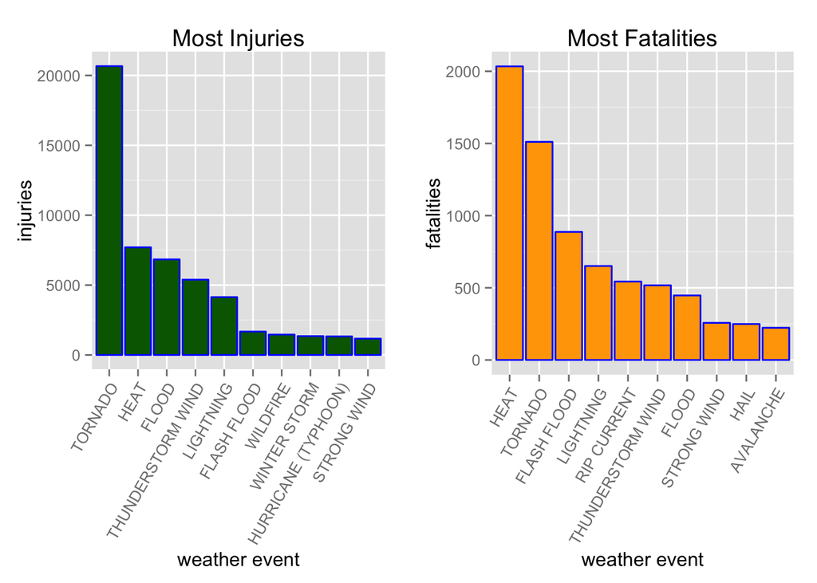

```r
injury <- ggplot(injurySummary[1:10,],
                 aes(x=reorder(event, desc(injuries)), y=injuries)) +
                        geom_bar(stat = "identity", fill = "dark green",
                                 color = "blue") +
                        labs(x = "weather event", y = "injuries",
                        title = "Most Injuries") +
                        theme(axis.text.x = element_text(angle = 60,
                                                         hjust = 1))

fatality <- ggplot(fatalitySummary[1:10,],
                   aes(x = reorder(event, desc(fatalities)),
                       y = fatalities)) +
                        geom_bar(stat = "identity",
                                 fill = "orange", color = "blue") +
                        labs(x = "weather event", y = "fatalities",
                        title = "Most Fatalities") +
                        theme(axis.text.x = element_text(angle = 60, hjust = 1))

grid.arrange(injury, fatality, ncol = 2)
```

*Figure 1.* Comparison plots of U.S. injuries and fatalities by weather event.

### Across the United States, which types of events have the greatest economic consequences?

```r
slice(cropDamageSummary, 1:10)
```

```
## Source: local data frame [10 x 2]
##
##                  event cropDamage
## 1              DROUGHT 13.3675660
## 2  HURRICANE (TYPHOON)  5.3501078
## 3                FLOOD  5.0131615
## 4                 HAIL  2.5791687
## 5         FROST/FREEZE  1.3687610
## 6                 COLD  1.3391155
## 7          FLASH FLOOD  1.3349017
## 8    THUNDERSTORM WIND  1.0172499
## 9           HEAVY RAIN  0.7399198
## 10      TROPICAL STORM  0.6777110
```

*Table 3.* Weather events with total crop damages in billions US$

```r
slice(propertyDamageSummary, 1:10)
```

```
## Source: local data frame [10 x 2]
##
##                  event propertyDamage
## 1  HURRICANE (TYPHOON)      81.718889
## 2            HIGH SURF      43.288930
## 3                FLOOD      29.245582
## 4              TORNADO      24.616953
## 5          FLASH FLOOD      15.222269
## 6                 HAIL      14.650966
## 7    THUNDERSTORM WIND       8.052492
## 8             WILDFIRE       7.760450
## 9       TROPICAL STORM       7.642476
## 10         STRONG WIND       5.252512
```

*Table 4.* Weather events with total property damages in billions US$

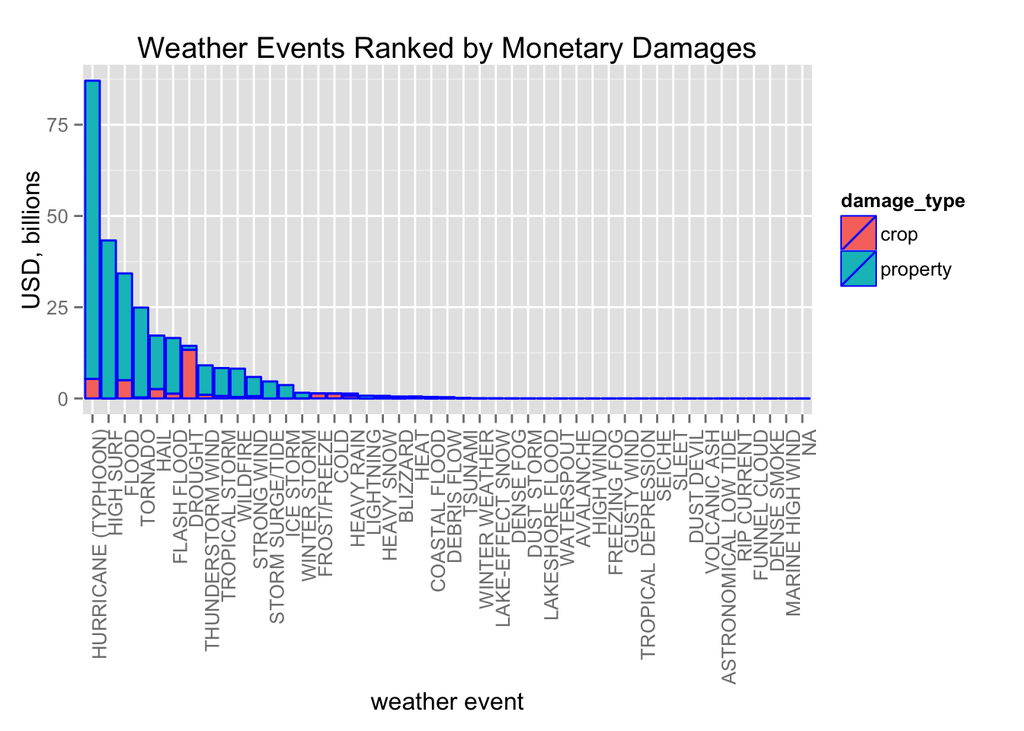

```r
gatherDamages <- gather(damageSummary, "damage_type", "USD_in_billions",
                        crop:property)

damages <- ggplot(gatherDamages,
                  aes(x = reorder(event, desc(USD_in_billions)),
                      y = USD_in_billions, fill = damage_type)) +
                geom_bar(stat = "identity", color = "blue") +
                labs(x = "weather event", y = "USD, billions",
                 title = "Weather Events Ranked by Monetary Damages") +
                theme(axis.text.x = element_text(angle = 90, hjust = 1))
print(damages)
```

*Figure 2.* Comparison of U.S. property and crop damages in billions US$